# Notebook

Brian Roth

## Project Description

The goal of this project is to determine if there are any correlations between a Spotify playlist’s follower count and the audio features (danceability, energy, instrumentalness, etc.) of the tracks inside the playlist. The analysis will include initial exploratory data plots to understand the data set at a high-level overview, followed by the construction of several regression models, concluded by an analysis of the models to decide which one is able to predict follower counts best.

The models that will be constructed are: 1) multiple linear regression, 2) k-Nearest Neighbors, and 3) random forest.

## Explanation of Data

There are four main data sets that we’ll be working with. The data was gathered using Spotify’s public API via an external Node.js script. The data has been stored in a MySQL database, and will be retrieved here in R from the database.

**1. Set of all playlists that have been curated by Spotify (user id: “Spotify”)**

I decided that I’d only use playlists that have been curated by Spotify themselves. This will ensure fair visibility of the playlists on the platform, and will likely provide the widest range of tracks within a reasonable amount of querying the API.

**2. Set of all unique tracks that are inside the set of all playlists curated by Spotify**

**3. Mapping of tracks to playlists**

Since it is possible for the same track to be included in more than one playlist in our data set, this mapping is required to ensure normalization of the database.

**4. Audio features for every track that is inside a playlist curated by Spotify**

Most tracks on Spotify have an associated list of “audio features”, which are normalized values between 0 and 1 (with the exception of musical key, which is based on a mapping of key to integer). Audio features include: danceability, loudness, tempo, etc. A detailed description of each of the audio features is available on Spotify’s developer website [here](https://developer.spotify.com/web-api/get-audio-features/).

The following block of code will initialize all the libraries that will be used in this R Notebook. The libraries will allow us to pull data from our MySQL database, and perform analysis on our data.

```r
# Initialize all libraries
library(RMySQL)
library(caret)
library(randomForest)
library(corrplot)
library(tidyr)
library(scales)
```

## Database Imports

The following block of code creates a connection to the MySQL database. Note that you may need to change some of the values below depending on your local MySQL setup, and possibly add a `password` parameter as well to connect to the database.

```r
# Initialize a connection to the MySQL database
dbConnection <- dbConnect(
  MySQL(),
  user = "root",
  dbname = "ds4100project",
  host = "localhost"
)
```

The following block of code will retrieve all rows from the `playlists` table in the database, and store it in a data frame called `playlists`. Note that this block only runs if the `playlists` variable doesn’t already exist in the global environment.

```r
if (!exists("playlists")) {
  dbQuery <- dbSendQuery(dbConnection, "SELECT * FROM playlists")
  playlists <- fetch(dbQuery, n = -1) # n = -1 to override RMySQL's default behavior of returning only 500 rows
}
```

The following block of code will retrieve all rows from the `tracks` table in the database, join it with the `track_audio_features` table in the database, and store it in a data frame called `tracks`. Note that this block only runs if the `tracks` variable doesn’t already exist in the global environment.

This will give us access to all of the unique tracks across our data set, along with the audio features for every track. Note that if a track doesn’t have audio features stored in the database, it won’t be included in this data frame.

```r
if (!exists("tracks")) {
  dbQuery <- dbSendQuery(dbConnection, "SELECT * FROM tracks JOIN track_audio_features WHERE tracks.id = track_audio_features.id")
  tracks <- fetch(dbQuery, n = -1) # n = -1 to override RMySQL's default behavior of returning only 500 rows
}
```

The following block of code will retrieve all rows from the `tracks_to_playlists` table in the database, join it with the `track_audio_features` table in the database, join it with the `playlists` table in the database, and store it in a data frame called `df`. Note that this block only runs if the `df` variable doesn’t already exist in the global environment.

This data frame is going to be our main data frame for analysis. It contains essentially all of the information we need to know for analysis, including tracks, track audio features, and playlist follower counts.

```r
dbQuery <- dbSendQuery(dbConnection, "SELECT tracks_to_playlists.playlist_id, track_audio_features.*, playlists.followers, playlists.name, tracks.duration_in_ms FROM tracks_to_playlists JOIN track_audio_features ON track_audio_features.id = tracks_to_playlists.track_id JOIN playlists ON playlists.id = tracks_to_playlists.playlist_id JOIN tracks ON tracks.id = tracks_to_playlists.track_id")
df <- fetch(dbQuery, n = -1) # n = -1 to override RMySQL's default behavior of returning only 500 rows
```

## Exploratory data plots

Let’s begin by simply taking a look at some basic data plots exploration. This will give us a better idea of the range of data we’re working with, and allow us to shape the next step of the pipeline, which is data cleaning and normalization.

First, the following will determine how many playlists we have pulled from our database (and thus, the Spotify API).

```r
print(paste("We have", nrow(playlists), "saved playlists."))
```

```
[1] "We have 1639 saved playlists."
```

Next, let’s determine the mean and median follower counts for our playlists. It doesn’t really make sense to calculate the mode here, since there’s such great variability in the follower counts.

```r
print(paste("The mean follower count is", mean(playlists$followers, na.rm = TRUE)))
```

```
[1] "The mean follower count is 253667.946930946"
```

```r
print(paste("The median follower count is", median(playlists$followers, na.rm = TRUE)))
```

```
[1] "The median follower count is 39746.5"
```

Now, let’s find out what the highest follower count is across our data set. We also determine here the number of playlists that are missing a follower count. It’s important to note that it is possible that these playlists have either 0 followers, or Spotify’s API failed to return any value for follower count. Unfortunately, it’s not possible for us to know which of these cases it is for a given playlist, so these missing values are something we’ll need to deal with in the data shaping stage. This information might also be useful later on in the detection of outliers.

```r
highestFollowerCount <- playlists[which.max(playlists$followers), ]
print(paste("The highest follower count is", highestFollowerCount$followers,". It is playlist id", highestFollowerCount$id, "titled", highestFollowerCount$name))
```

```
[1] "The highest follower count is 19600414 . It is playlist id 37i9dQZF1DXcBWIGoYBM5M titled Today's Top Hits"
```

```r
print(paste("Meanwhile, there are", nrow(playlists[is.na(playlists$followers), ]), "playlists with a missing follower count."))
```

```
[1] "Meanwhile, there are 75 playlists with a missing follower count."
```

Switching over to tracks, let’s see how many total across all playlists we have. Note that these are the unique tracks, since more than one playlist might contain the same track. As stated earlier, this count also takes into account that we’re only going to work with tracks that have audio features (which is almost all of the unique tracks in our data set, but not all).

```r
print(paste("There is a total of", nrow(tracks), "tracks (with audio features)."))
```

```
[1] "There is a total of 74588 tracks (with audio features)."
```

Let’s create a simple histogram (frequency distribution) of follower counts across our playlists. Note that since we have such a wide range of data for follower counts, the x-axis in the histogram below is on a logarithmic scale in order to more accurately display the breadth of playlists. Without the logarithmic base, our data would be almost entirely skewed to the left of the graph, with a few outliers towards the right.

As we can see by the distribution, playlist follower counts are mostly skewed to the right of the graph. This means that most playlists in our data set have a large amount of follower counts, and fewer have smaller counts.

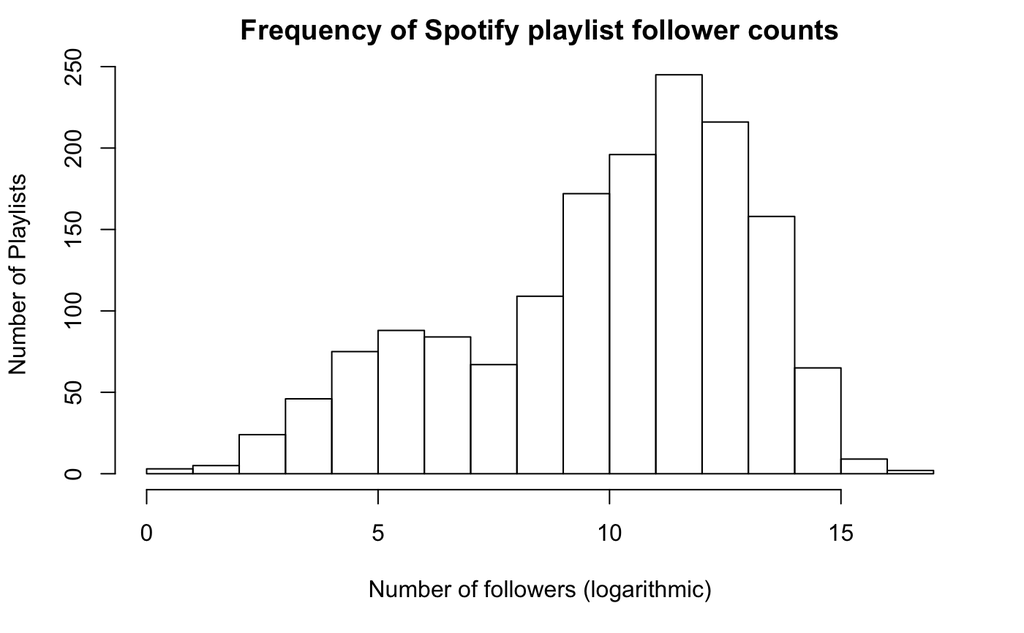

```r
hist(
  x = log(playlists$followers),
  ylab = "Number of Playlists",
  xlab = "Number of followers (logarithmic)",
  main = "Frequency of Spotify playlist follower counts"
)
```

## Collapsing Data

The following code is extremely critical to the rest of the analysis. Our current data frame `df` contains track audio features at the track level. This isn’t helpful to us since our goal is to look at follower count correlations at the playlists level, so we need a way to collapse our track audio data to the playlist level.

In order to do this, we run a mean aggregation across all of the quantitative features inside `df`, that is, the columns related to the track audio features (danceability, energy, etc.), and collapse on `playlist_id`.

This will leave us with a data frame whose row count is almost equal to the number of playlists we have in our data set. It’s not exactly equal because some playlists might not have any tracks associated with them in our data set. We can now perform analysis of the track audio features at a playlist level.

```r
# Playlist ID, followers, and name won't be collapsed on
aggregateDF <- aggregate(
  cbind(danceability, energy, integer_key, loudness, mode, speechiness, instrumentalness, liveness, valence, tempo, duration_in_ms) ~ playlist_id + followers + name,
  data = df,
  FUN = mean
)
```

## Standardization

Next, let’s standardize our follower counts in order to detect any outliers. First, we’re going to eliminate any playlists with follower counts of 0 or `NA`, since these are not indicative of the majority of playlists in our data set. There are several factors that could contribute to this value for follower counts, including Spotify API limitations, so it’s easier to remove these from our data set instead of impute.

In order to standardize, we’ll run a simple z-score across the data set and store it in a new column called “standardizedFollowers.” Then, we’ll detect outliers by finding and removing any rows that have `abs(standardizedFollowers)` >= 3.

There’s a lot of possible explanations as to why these playlists have such high follower counts (or, low follower counts). For example, Spotify could be heavily marketing these playlists to users, so follower counts would be artificially high. It’s also possible that there is some correlation between the types of tracks in these playlists and the follower count, but we’ll save that for analysis later.

Note that this code block will only run if we haven’t already run the standardization code on the data frame (to avoid some strange issues with double standardizing the same column).

```r
if (!"standardizedFollowers" %in% colnames(aggregateDF)) {
  aggregateDF$standardizedFollowers <- scale(aggregateDF$followers)
  outliers <- aggregateDF[abs(aggregateDF$standardizedFollowers) >= 3, ]
  aggregateDF <- aggregateDF[abs(aggregateDF$standardizedFollowers) < 3, ]
  print(paste("There are", nrow(outliers), "playlists who have follower counts that we are considering outliers."))
  print(outliers$name)
}
```

```
[1] "There are 20 playlists who have follower counts that we are considering outliers."
 [1] "¡Viva Latino!"               "Are & Be"                    "Chill Hits"
 [4] "Deep Focus"                  "Get Turnt"                   "Have a Great Day!"
 [7] "Hit Rewind"                  "Hot Country"                 "mint"
[10] "New Music Friday"            "Peaceful Piano"              "RapCaviar"
[13] "Relax & Unwind"              "Rock Classics"               "Rock This"
[16] "Songs to Sing in the Shower" "Teen Party"                  "This Is Ed Sheeran"
[19] "Today's Top Hits"            "Your Favorite Coffeehouse"
```

There are four other variables that we need to standardize between 0 and 1 in our data set. Let’s do that now using the `rescale()` function. Instead of storing the standardized features in a new column, we’ll simply replace the current value with the standardized value in the data frame.

```r
aggregateDF$integer_key <- rescale(aggregateDF$integer_key)
aggregateDF$loudness <- rescale(aggregateDF$loudness)
aggregateDF$tempo <- rescale(aggregateDF$tempo)
aggregateDF$duration_in_ms <- rescale(aggregateDF$duration_in_ms)
```

## Correlation Analysis

To begin analyizing our data, we’ll run a correlation test to create a correlation matrix. This will allow us to determine which variables in our data set correlate to another variable (or multiple variables). We’ll be using a Pearson correlation here, since it’s better than Spearman for continuous variables like the ones we are working with.

One should actually expect to see results like the ones we found. For instance, it’s likely that the danceability of a song will be lower if it is more instrumental, and similarly with valence and loudness. On the other hand, variables like danceability and valence are strongly correlated because songs are more likely to be danceable if they are happy-sounding (valence scale).

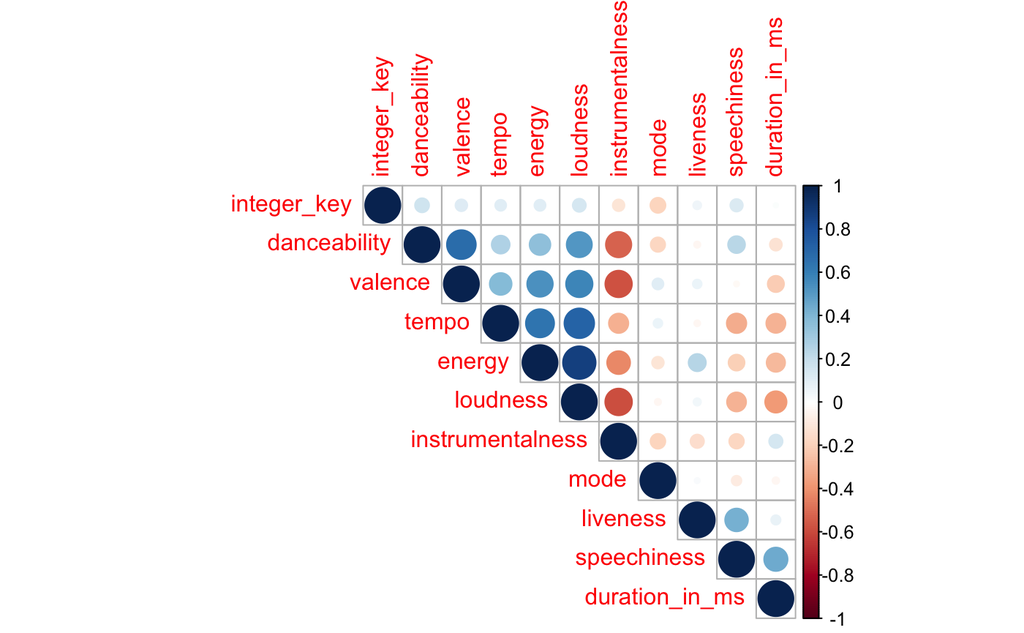

```r
correlationMatrix <- cor(
  aggregateDF[c(4:14)],
  method = "pearson",
  use = "complete.obs"
)
corrplot(
  correlationMatrix,
  type = "upper",
  order = "hclust"
)
```

## Generation of training, test, and validation data sets

The first necessary step before constructing different models and evaluating them is to split our data set into training, validation, and test data sets. The training set will be comprised of 60% of our data set, and the test and validation will make up the remaining 40% evenly. The training set will be used to train our models. The validation set will be used to tune our model, and the test set will be used to test our model against the remaining rows of data.

```r
# Adapted from https://stackoverflow.com/questions/36068963/r-how-to-split-a-data-frame-into-training-validation-and-test-sets
spec <- c(train = 0.6, test = 0.2, validate = 0.2)
g <- sample(cut(
  seq(nrow(aggregateDF)),
  nrow(aggregateDF)*cumsum(c(0,spec)),
  labels = names(spec)
))
modelFrames <- split(aggregateDF, g)
```

## Baseline Model

Before we begin with more advanced models, let’s take a look at the baseline model. The baseline model will be computed by taking the mean follower across in our training data set, and then calculating the RMSE and MAE on the test data.

Both the RMSE and MAE are relatively significantly different than what we expected to be the follower count, so this isn’t a good model to use for prediction. Let’s try another model.

```r
baselineFollowers <- mean(modelFrames$train$followers)
print(paste("Mean follower count of the training set:", baselineFollowers))
```

```
[1] "Mean follower count of the training set: 203289.24025974"
```

```r
baselineRMSE <- print(paste("RMSE:", sqrt(mean((baselineFollowers - modelFrames$test$followers)^2))))
```

```
[1] "RMSE: 389183.42404986"
```

```r
baselineMAE <- print(paste("MAE:", mean(abs(baselineFollowers - modelFrames$test$followers))))
```

```
[1] "MAE: 250937.507800641"
```

## Linear Regression

Next, we’ll run a linear regression on our training set to detect a correlation between follower count across all available variables (danceability + energy + integer_key + loudness + mode + speechiness + instrumentalness + liveness + valence + tempo + duration_in_ms) for the quantitative features of that playlist. Note that we are going to use the log(followers) in the `lm()` function, since our data is skewed to the right and to get more reasonable follower count numbers.

We’ll also utilize the tactic of back-fitting of regression parameters, which calls for us to remove the least-significant variable in each `lm()` until the only remaining variables are statistically significant. The final iteration of the linear model is our ideal model, with statistically significant variables included.

```r
linearModel <- lm(
  formula = log(followers) ~ danceability + energy + integer_key + loudness + mode + speechiness + instrumentalness + liveness + valence + tempo + duration_in_ms,
  data = modelFrames$train
)
linearModel <- lm(
  formula = log(followers) ~ danceability + energy + integer_key + loudness + mode + speechiness + instrumentalness + liveness + valence + tempo,
  data = modelFrames$train
)
linearModel <- lm(
  formula = log(followers) ~ danceability + energy + integer_key + loudness + mode + speechiness + liveness + valence + tempo,
  data = modelFrames$train
)
linearModel <- lm(
  formula = log(followers) ~ danceability + energy + integer_key + mode + speechiness + liveness + valence + tempo,
  data = modelFrames$train
)
linearModel <- lm(
  formula = log(followers) ~ danceability + energy + integer_key + mode + speechiness + liveness + valence,
  data = modelFrames$train
)
linearModel <- lm(
  formula = log(followers) ~ danceability + integer_key + mode + speechiness + liveness + valence,
  data = modelFrames$train
)
linearModel <- lm(
  formula = log(followers) ~ danceability + integer_key + mode + speechiness + valence,
  data = modelFrames$train
)
linearModel <- lm(
  formula = log(followers) ~ danceability + integer_key + speechiness + valence,
  data = modelFrames$train
)
idealLinearModel <- lm(
  formula = log(followers) ~ danceability + speechiness + valence,
  data = modelFrames$train
)
summary(idealLinearModel)
```

```
Call:
lm(formula = log(followers) ~ danceability + speechiness + valence,
    data = modelFrames$train)

Residuals:
     Min       1Q   Median       3Q      Max
-10.5243  -1.6253   0.8453   2.1692   5.2506

Coefficients:
             Estimate Std. Error t value Pr(>|t|)
(Intercept)    9.5780     0.4344  22.046  < 2e-16 ***
danceability   5.2377     1.1224   4.666 3.52e-06 ***
speechiness   -2.1263     0.6235  -3.410 0.000678 ***
valence       -4.9670     0.8218  -6.044 2.19e-09 ***
---
Signif. codes:  0 ‘***’ 0.001 ‘**’ 0.01 ‘*’ 0.05 ‘.’ 0.1 ‘ ’ 1

Residual standard error: 2.959 on 920 degrees of freedom
Multiple R-squared:  0.04194,   Adjusted R-squared:  0.03881
F-statistic: 13.42 on 3 and 920 DF,  p-value: 1.404e-08
```

The following is Spotify’s description of the statistically significant audio features:

### Valence

> A measure from 0.0 to 1.0 describing the musical positiveness conveyed by a track. Tracks with high valence sound more positive (e.g. happy, cheerful, euphoric), while tracks with low valence sound more negative (e.g. sad, depressed, angry).

### Danceability

> Danceability describes how suitable a track is for dancing based on a combination of musical elements including tempo, rhythm stability, beat strength, and overall regularity. A value of 0.0 is least danceable and 1.0 is most danceable.

### Speechiness

> Speechiness detects the presence of spoken words in a track. The more exclusively speech-like the recording (e.g. talk show, audio book, poetry), the closer to 1.0 the attribute value. Values above 0.66 describe tracks that are probably made entirely of spoken words. Values between 0.33 and 0.66 describe tracks that may contain both music and speech, either in sections or layered, including such cases as rap music. Values below 0.33 most likely represent music and other non-speech-like tracks.

Now we’ll take a closer look at each of these significant variables to understand what’s going on.

Let’s create a plot for valence vs. follower count (again, in a logarithmic base). The x-axis here will be the follower count, and the y-axis will be the average valence for that playlist.

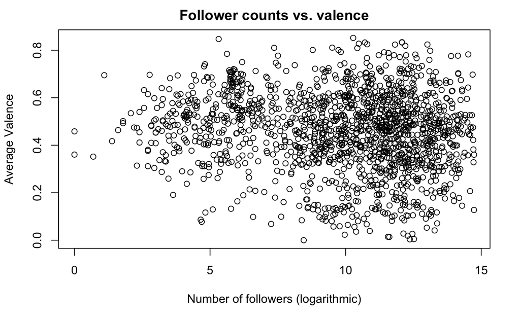

```r
plot(
  x = log(aggregateDF$followers),
  y = aggregateDF$valence,
  ylab = "Average Valence",
  xlab = "Number of followers (logarithmic)",
  main = "Follower counts vs. valence"
)
```

Let’s create a plot for danceability vs. follower count (again, in a logarithmic base). The x-axis here will be the follower count, and the y-axis will be the average danceability for that playlist.

We can see that the points in the plot are mostly concentrated in the top-right hand corner of the plot. This means that most playlists with higher follower counts contain tracks with mostly high danceability values (closer to 1.0). According to Spotify’s documentation, this danceability value correlates to highly danceable tracks. One would guess that this makes sense because people enjoy danceable tracks and would listen to them more often that tracks that are less danceable.

It’s also worth noting the few outliers on the plot, mostly concentrated to the bottom of the plot. These playlists have high follower counts, but very non-danceable tracks.

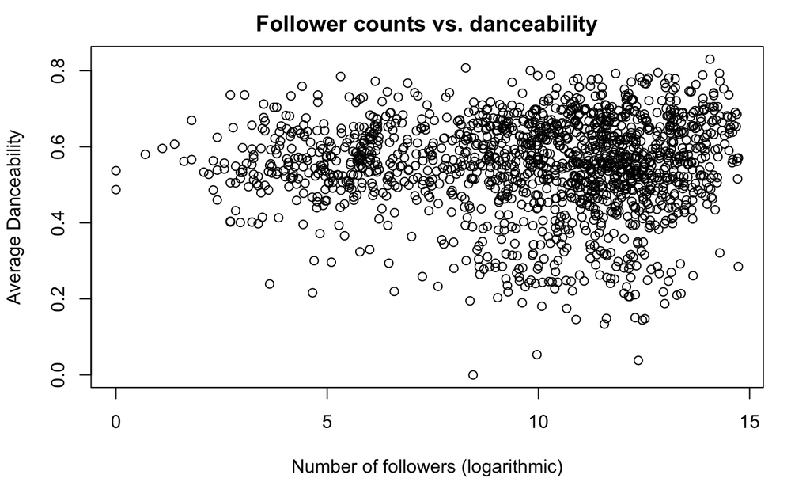

```r
plot(
  x = log(aggregateDF$followers),
  y = aggregateDF$danceability,
  ylab = "Average Danceability",
  xlab = "Number of followers (logarithmic)",
  main = "Follower counts vs. danceability"
)
```

Let’s create a plot for speechiness vs. follower count (again, in a logarithmic base). The x-axis here will be the follower count, and the y-axis will be the average speechiness for that playlist.

We can see that the points in the plot are mostly concentrated in the bottom-right hand corner of the plot. This means that most playlists with higher follower counts contain tracks with very low speechiness values. According to Spotify’s documentation, lower speechiness values correlate to tracks that are more musical rather than things like podcasts, audiobooks, etc.

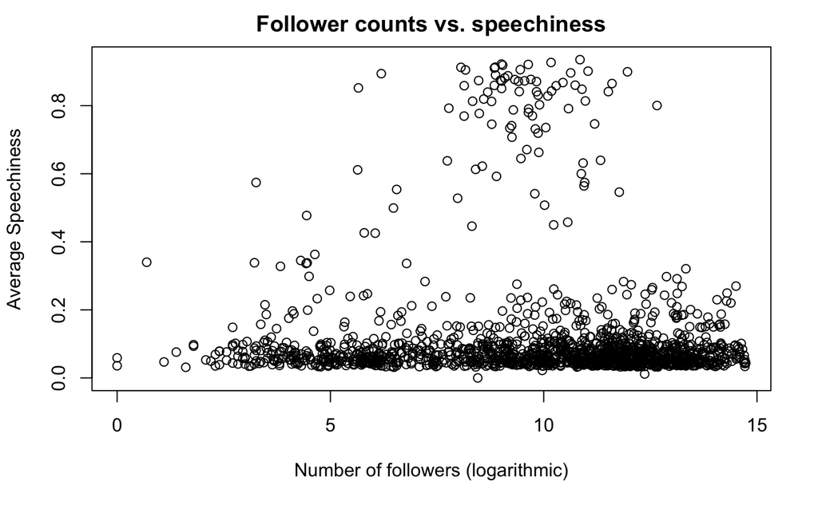

```r
plot(
  x = log(aggregateDF$followers),
  y = aggregateDF$speechiness,
  ylab = "Average Speechiness",
  xlab = "Number of followers (logarithmic)",
  main = "Follower counts vs. speechiness"
)
```

To close out the linear regression modeling, let’s create an ideal model using the significant variables from our original model. Again, this model includes the statistically significant variables from the model above, which contained all variables. We’ll then use the model we build to predict follower counts using the `predict()` function (which will be run against the test set).

```r
idealLinearModelPred <- predict(idealLinearModel, modelFrames$test)
lrRMSE <- print(paste("RMSE:", sqrt(mean((idealLinearModelPred - modelFrames$test$followers)^2))))
```

```
[1] "RMSE: 437162.258198648"
```

```r
lrMAE <- print(paste("MAE:", mean(abs(idealLinearModelPred - modelFrames$test$followers))))
```

```
[1] "MAE: 199158.903580406"
```

## k-Nearest Neighbors

The k-nearest neighbors (kNN) algorithm for regression attempts to output a predicted value (in our case, of follower counts for a playlist) based on distances between variables in the regression model. We’ll run a kNN regression across all variables in our data set to predict the logarithmic follower count for playlists. As usual, the model will be trained using the training set, and a prediction will be run on the test data set to see how accurate the model is.

```r
set.seed(100)
knnModel <- train(
  log(followers) ~ danceability + energy + integer_key + loudness + mode + speechiness + instrumentalness + liveness + valence + tempo + duration_in_ms,
  data = modelFrames$train,
  method = "knn",
  trControl = trainControl(method = "repeatedcv", number = 5),
  tuneLength = 20 # a reasonable value for tuning
)
knnModel
```

```
k-Nearest Neighbors

924 samples
 11 predictor

No pre-processing
Resampling: Cross-Validated (5 fold, repeated 1 times)
Summary of sample sizes: 739, 740, 740, 738, 739
Resampling results across tuning parameters:

  k   RMSE      Rsquared    MAE
   5  3.086101  0.04520767  2.431242
   7  2.975053  0.06502270  2.356722
   9  2.978461  0.05737337  2.366602
  11  2.968616  0.05720559  2.367823
  13  2.937292  0.06795206  2.351757
  15  2.936768  0.06506483  2.350815
  17  2.927081  0.06813841  2.337918
  19  2.921429  0.06968482  2.337784
  21  2.928805  0.06383500  2.351934
  23  2.932132  0.06252399  2.356689
  25  2.940019  0.05865841  2.368162
  27  2.936973  0.06295451  2.367484
  29  2.939713  0.05845248  2.365761
  31  2.942291  0.05522947  2.368529
  33  2.938022  0.05625843  2.370517
  35  2.949971  0.04831521  2.380323
  37  2.951377  0.04667074  2.387273
  39  2.954977  0.04392443  2.393524
  41  2.963989  0.03895844  2.404189
  43  2.961564  0.03928886  2.404354

RMSE was used to select the optimal model using the smallest value.
The final value used for the model was k = 19.
```

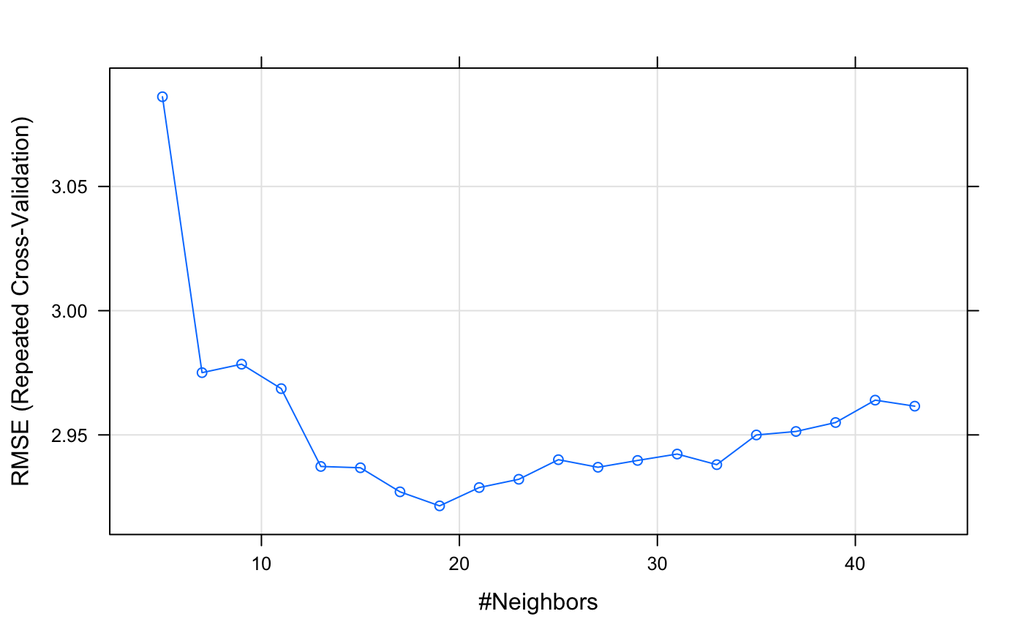

```r
plot(knnModel)
```

```r
knnPredict <- predict(knnModel, modelFrames$test)
knnRMSE <- print(paste("RMSE:", sqrt(mean((knnPredict - modelFrames$test$followers)^2))))
```

```
[1] "RMSE: 437162.144454486"
```

```r
knnMAE <- print(paste("MAE:", mean(abs(knnPredict - modelFrames$test$followers))))
```

```
[1] "MAE: 199158.712460912"
```

## Random Forest

The random forest algorithm for regression attempts to predict some output (in our case, of follower counts for a playlist) by binning predicted data by creating a tree. The random forest’s leaf nodes become the predicted value. Random forests are especially useful for and good predictors with non-categorical features (like the follower counts that we are working with).

To run this algorithm, we will create a random forest with 100 trees, and also analyze the “importance” of each variable, meaning how critical its inclusion is to creating a better predicting tree.

```r
set.seed(100)
randomForestModel <- randomForest(
  log(followers) ~ danceability + energy + integer_key + loudness + mode + speechiness + instrumentalness + liveness + valence + tempo + duration_in_ms,
  data = modelFrames$train,
  importance = TRUE,
  ntree = 100
)
randomForestModel
```

```
Call:
 randomForest(formula = log(followers) ~ danceability + energy +      integer_key + loudness + mode + speechiness + instrumentalness +      liveness + valence + tempo + duration_in_ms, data = modelFrames$train,      importance = TRUE, ntree = 100)
               Type of random forest: regression
                     Number of trees: 100
No. of variables tried at each split: 3

          Mean of squared residuals: 8.207504
                    % Var explained: 9.83
```

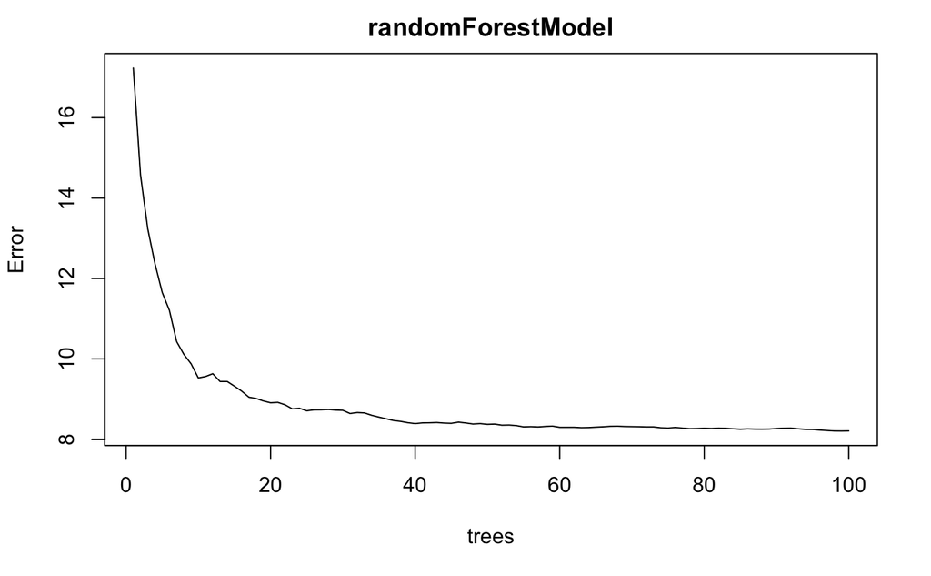

```r
plot(randomForestModel)
```

```r
randomForestModelImportance <- as.data.frame(sort(
  importance(randomForestModel)[, 1],
  decreasing = TRUE),
  optional = TRUE
)
print(randomForestModelImportance)
```

| valence | 9.544971 |
| --- | --- |
| danceability | 9.530322 |
| duration_in_ms | 8.315139 |
| energy | 7.558286 |
| loudness | 5.804539 |
| instrumentalness | 5.353565 |
| liveness | 5.193729 |
| speechiness | 4.515343 |
| tempo | 3.949905 |
| mode | 3.767515 |

[output cut: 1 more lines]

```r
randomForestPredict <- predict(randomForestModel, modelFrames$test)
randomForestRSME <- print(paste("RSME:", sqrt(mean((randomForestPredict - modelFrames$test$followers)^2))))
```

```
[1] "RSME: 437162.054135247"
```

```r
randomForestMAE <- print(paste("MAE:", mean(abs(randomForestPredict - modelFrames$test$followers))))
```

```
[1] "MAE: 199158.872241235"
```

Let’s create some plots to better visualize this. We’ll create three plots, each compare the logarithmic follower count to the respective prediction model.

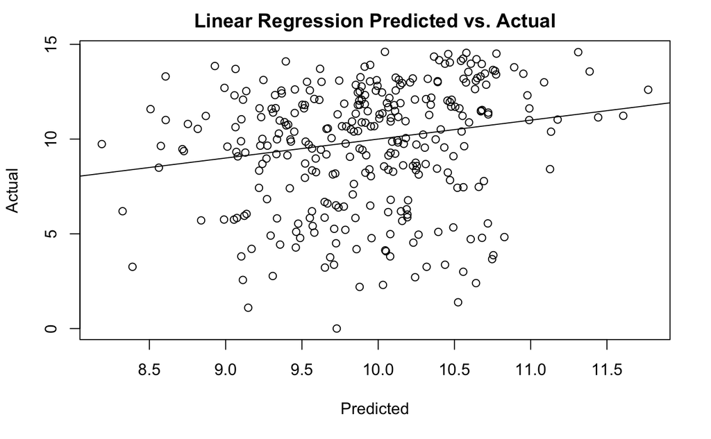

```r
plot(
  idealLinearModelPred,
  log(modelFrames$test$followers),
  xlab = "Predicted",
  ylab = "Actual",
  main = "Linear Regression Predicted vs. Actual"
)
abline(
  a = 0,
  b = 1
)
```

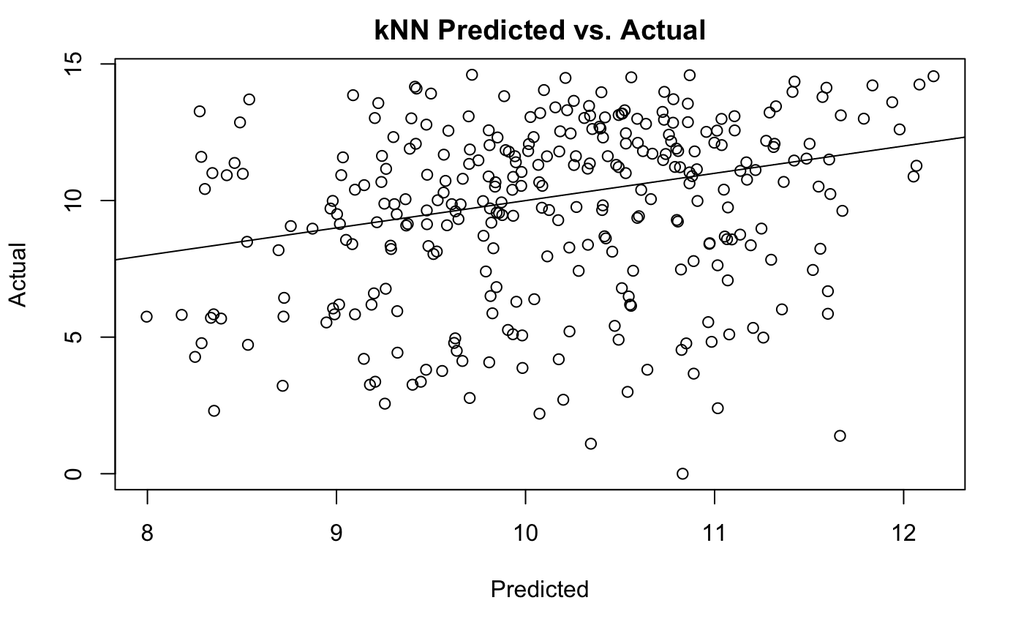

```r
plot(
  knnPredict,
  log(modelFrames$test$followers),
  xlab = "Predicted",
  ylab = "Actual",
  main = "kNN Predicted vs. Actual"
)
abline(
  a = 0,
  b = 1
)
```

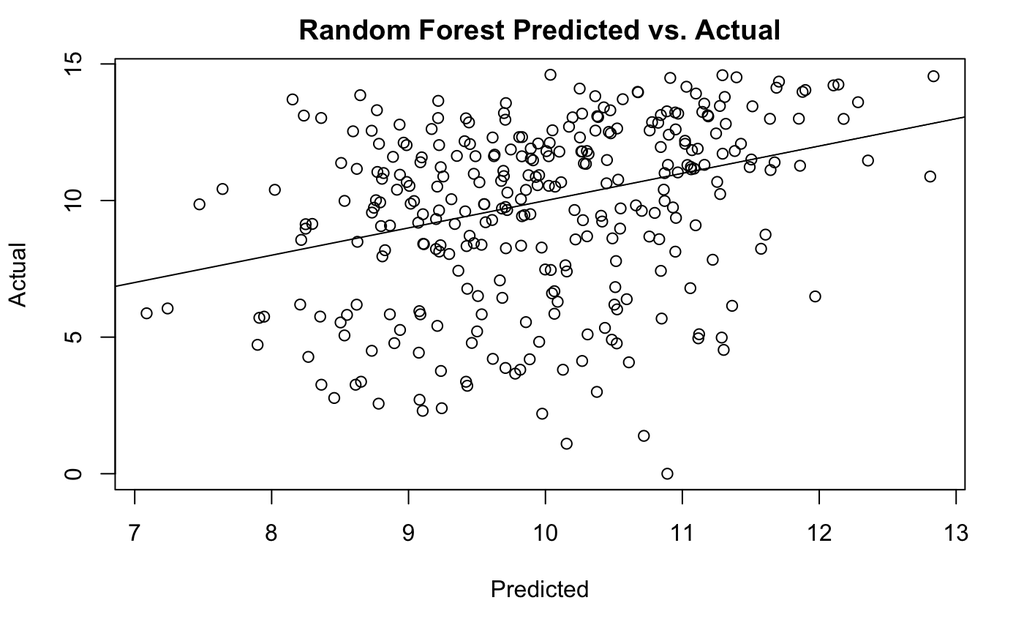

```r
plot(
  randomForestPredict,
  log(modelFrames$test$followers),
  xlab = "Predicted",
  ylab = "Actual",
  main = "Random Forest Predicted vs. Actual"
)
abline(
  a = 0,
  b = 1
)
```

## Conclusion

The goal of this project was to determine if there are any correlations between the type of tracks in a playlist and the follower count of that playlist on Spotify. To begin, we pulled down almost 1700 playlists using the Spotify API, stored the data in a MySQL database, and imported it into R for analysis. We began by performing some exploratory data plots, and then created three different types of regression models for predicting the follower counts of playlists based on the track audio features.

In the future, one could expand this project to inlcude more factors like artists, track genres, etc. in determining if there are any other statistically significant variables that can predict playlist follower counts.